Class, the below is a standard set of instructions for each HW, in this assignment groups will be set up for collaboration.  
Make sure your group starts one thread for the collaborative problems. You are required to participate in the collaborative problem and subproblem separately. Please do not directly post a complete solution, the goal is for the group to develop a solution after everyone has participated. Please ensure you have a write-up with solutions to each problem and subproblems, you are also required to submit code that will be compiled when grading the assignment.

# **1. Module 3 Note this is not a Collaborative Problem**

*30 Points Total*  
In this problem use the seaborn Python package to create a scatter plot matrix of the Iris data set.

1. [10 points] Examine the Seaborn plots provided down the diagonal and present a clear and concise explanation for these plots.
2. [10 points] Does any feature separate the three classes? If so, which feature? If not, which is the closest?
3. [10 points] Is there any combination of features that can separate the three classes? If so, which features? If not, which are the closest?

Reference: https://seaborn.pydata.org/examples/scatterplot_matrix.html

```python
## import libraries
import seaborn as sns
import numpy as np
import pandas as pd
import pywt
from matplotlib import pyplot as plt

# Import datasets
from sklearn.datasets import load_iris, fetch_openml
```

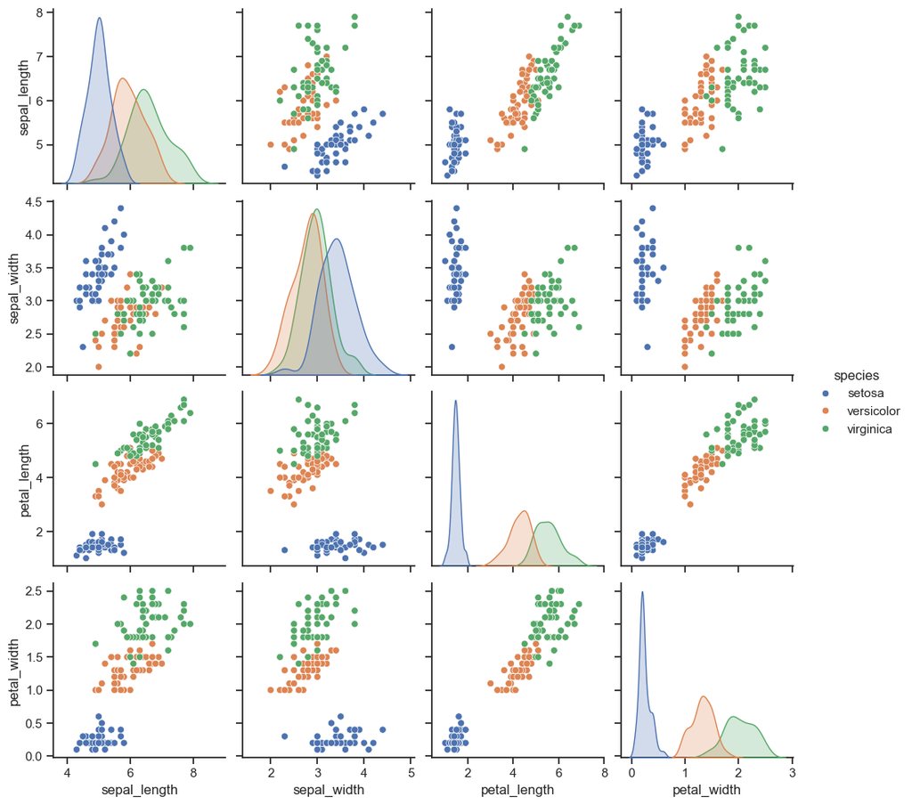

```python
## Type code here for the part 1 ##
sns.set_theme(style="ticks")

df = sns.load_dataset("iris")
sns.pairplot(df, hue="species")
```

1. The plots down the diagonal show univariate distribution plots drawn to show the marginal distribution of the data in each column
2. No feature separates the three classes completely, but petal width shows the most separation of the 4 features.
3. There is no combination of features that completely separates the three class, it looks like petal_width x petal_length comes the closest (to my eye).

# References

[1] https://seaborn.pydata.org/generated/seaborn.pairplot.html#seaborn.pairplot

# **2. Module 4 Note this is a Collaborative Problem**

*30 Points Total*  
In this problem, implement code to use the Mahalanobis Distance on the Iris dataset. You may NOT use the built-in function in Python.

1. [10 points] Using all four features, calculate the 50 distances for the Setosa class.
2. [5 points] Calculate the range (min and max) of the 50 Mahalanobis distance values. What is the delta between the min and the max?
3. [10 points] If you remove the observation with the largest distance, do the remaining distances appear to be closer together? After removing the observation with the largest distance, recalculate the ranges with the updated mean and covariance. Does removing the observation with the largest Mahalanobis distance provide a smaller range between the min and max?
4. [5 points] Given your findings, describe what was accomplished following the method above this data point from the dataset.

```python
## Type code here for part 1 ##

def mahalanobis_distance(sample, mean_vector, cov):
    """
    Calculates the Mahalanobis distance between two vectors.
    Uses the following formula: D^2 = (u - v)^T * cov^-1 * (u - v)
    """

    # Calculate the difference between the vectors.
    diff = sample - mean_vector

    # Calculate the dot product of the difference and the inverse of the covariance matrix.
    dot = np.dot(diff.T, cov)

    # Calculate the Mahalanobis distance by taking the square root of the dot product of the difference and the inverse of the covariance matrix.
    md = np.sqrt(np.dot(dot, diff))

    return md

# Get the dataset as a data frame
iris = load_iris(as_frame=True)

# Get the setosa data by filtering by target
setosa_data = iris.data[iris.target == 0]

# Calculate our mean
mean_vector = np.mean(setosa_data, axis=0)

# Calculate the covariance matrix
cov_matrix = np.cov(setosa_data.T)

m_distance = [mahalanobis_distance(sample, mean_vector, cov_matrix) for sample in setosa_data.values]
print(f"Distances: {m_distance}")
```

```
Distances: [0.05397956151382181, 0.19544038498128435, 0.19189835000513647, 0.2495602606054687, 0.062015379922554514, 0.31451440575682926, 0.15277342567291213, 0.013913919033009516, 0.39035336843032103, 0.15733322624808985, 0.2266154100709674, 0.07905749135139271, 0.2288543186913315, 0.41026660968254…
```

```python
## Type code here for part 2 ##

min_value = min(m_distance)
max_value = max(m_distance)
delta = max_value - min_value

print(f"Min: {min_value}, Max: {max_value}, Delta: {delta}")
```

```
Min: 0.013913919033009516, Max: 0.5801305528649108, Delta: 0.5662166338319012
```

```python
## Type code here for part 3 ##

# Get index of maximum mahalanobis distance value
max_distance_index = m_distance.index(max_value)

# Drop the row with the maximum mahalanobis distance value
setosa_data = setosa_data.drop(max_distance_index, axis='rows')

# Recalculate our mean and covariance matrix
mean_vector = np.mean(setosa_data, axis=0)
cov_matrix = np.cov(setosa_data.T)

# Calculate the new Mahalanobis distance for each sample
m_distance = [mahalanobis_distance(sample, mean_vector, cov_matrix) for sample in setosa_data.values]
print(f"Distances: {m_distance}")

# Calculate the new min, max, and delta
min_value = min(m_distance)
max_value = max(m_distance)
delta = max_value - min_value
print(f"Min: {min_value}, Max: {max_value}, Delta: {delta}")
```

```
Distances: [0.06213405277313566, 0.17258141319143966, 0.17166788896415383, 0.2250660950393367, 0.06869055606382284, 0.30860338072486243, 0.13778183470644043, 0.007235968651293379, 0.3585441810551278, 0.13608100605369797, 0.22645517026004292, 0.06608945712842841, 0.20387707643726294, 0.38024798478767…
Min: 0.007235968651293379, Max: 0.5333388173858751, Delta: 0.5261028487345817
```

## Type analysis for part 3 here

- The remaining distances appear to be closer together when the maximum distanced value is removed
- Removing the largest distanced value provides a smaller range (0.526 vs 0.566) between minimum and maximum distance values

## Type response for part 4 here

- The changes we observed when we removed the observation with the largest distance from our data set was a smaller overall spread of each individual data point from the rest of the distribution.
- Removal of this observation causes the average to change with changes the mahalanobis distance of each observation.
- This method allows you to get a numeric representation for how much a data point is an outlier while also taking into account the correlation of the data.

# **3. Module 4 Note this is not a Collaborative Problem**

*20 Points Total*

In this problem we would like to introduce you to data transformations that can be used in order to generate features and extract components of images. For this problem you will be working with the wavelet transform. You may use the built-in function for this. Please follow the steps outlined below.

1. [2 points] Read in the MNIST dataset.
2. [2 points] Reshape the arrays in order to visualize each image in the dataset (in the MNIST dataset, each row represents a 28x28 image).
3. [2 points] Find an index from the MNIST dataset that holds an image for the number 7, we will use this in the subsequent steps.
4. [6 points] Perform a wavelet transform on this image and retain only the vertical and diagonal components of this image.
5. [6 points] Perform the inverse transform to revert back to an image.
6. [2 points] Plot the image (using plt.imshow) and provide an analysis of what was accomplished in this problem.

```python
## Type code here for part 1 ##

# Load the MNIST dataset
mnist = fetch_openml('mnist_784', version=1)
print(mnist.data.shape)
```

```
(70000, 784)
```

```python
## Type code here for part 2 ##

# Reshape the images (28x28)
image = mnist.data.to_numpy()
reshaped_images = [image_values.reshape(28, 28) for image_values in image]
```

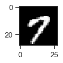

```python
## Type code here for part 3 ##

# Find the index of an image of a seven
seven_index = 15
plt.subplot(431)
plt.imshow(reshaped_images[seven_index], cmap='gray', interpolation='nearest')
```

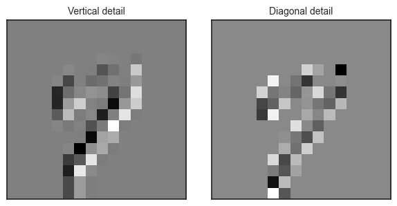

```python
## Type code here for part 4 ##

# Perform a wavelet transform on the image
coeffs2 = pywt.dwt2(reshaped_images[seven_index], 'bior1.3')

LL, (LH, HL, HH) = coeffs2

# Plot the transformed image
# Code inspired by https://pywavelets.readthedocs.io/en/latest/
titles = ['Vertical detail', 'Diagonal detail']
fig = plt.figure(figsize=(12, 3))
for i, a in enumerate([HL, HH]):
    ax = fig.add_subplot(1, 4, i + 1)
    ax.imshow(a, interpolation="nearest", cmap=plt.cm.gray)
    ax.set_title(titles[i], fontsize=10)
    ax.set_xticks([])
    ax.set_yticks([])

fig.tight_layout()
plt.show()
```

```python
## Type code here for part 5 ##

# invert the wavelet transform to get the image
reconstructed_image = pywt.idwt2(coeffs2, 'bior1.3')
```

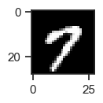

```python
## Type code here for part 6 ##

# Display the reconstructed image
plt.subplot(431)
plt.imshow(reconstructed_image, cmap='gray', interpolation='nearest')
```

# Problem Analysis

In this problem, we were able to:

1. Load the mnist dataset using sklearn, we use 'mnist_784' which gives us 784x1 image data
2. For each of the 70,000 images in the dataset, reshape each 784x1 image to be 28x28.
3. Find the index of an image with a '7'
4. Perform a wavelet transform on the image using pywavelets 2D discrete wavelet transform function dwt2. This function returns the approximation, horizontal / vertical detail, and diagonal detail as a tuple. We then plot them with labels
5. In this step we reconstruct the image using the inverse 2D discrete wavelet transform function idwt2 and get the original image back
6. We plot the original image to convince ourselves everything went okay.

# **4. Module 5 Note this is a Collaborative Problem**

*20 Points Total*

In this problem we would like to familiarize you with a basic example of a goal based agent. A game like rock paper scissors is typically played between two players and has a clearly defined set of rules for a win, draw, and loss. Since it is impossible (acknowledging that studies have been preformed to use behavior to attempt a prediction - but we will ignore that for the purpose of this exercise) to predict an opponent's move, we will assume that the user will input a value, the computer will see this input then choose from a set of rules the correct response play, acting as a simple goal based agent.

Instructions on how to play: https://www.wikihow.com/Play-Rock,-Paper,-Scissors

For this problem, you will fill in the rules (in if-then-else format) to the function in the cell below. The proceeding cell should then be run to play a game with the computer in which the computer agent should win every time.

```python
## Set Rock = 1, Paper = 2, Scissors = 3
## The funtion should read in the player_move and return the appropriate agent_play that will win the round
import random
def goal_based_agent(player_move=None):
    agent_play = None

    if player_move == 1:
        agent_play = 2
    elif player_move == 2:
        agent_play = 3
    elif player_move == 3:
        agent_play = 1

    return agent_play
```

```python
## Set Rock = 1, Paper = 2, Scissors = 3
## The program will receive player input for the number of rounds to be played: suggested to use 5 so that you may test your implementation
import sys

num_rounds = int(input("Enter number of rounds to be played: "))
curr_round = 1
win_counter = 0
while curr_round <= num_rounds:
    print("Enter choice \n 1 for Rock, \n 2 for paper, and \n 3 for scissor \n")

    # take the input from user
    player_move = int(input("User turn: "))

    if player_move == 1 or player_move == 2 or player_move == 3:
        if player_move == 1:
            choice_name = 'Rock'
        elif player_move == 2:
            choice_name = 'Paper'
        elif player_move == 3:
            choice_name = 'Scissor'

        print("Player move is: ", choice_name)

        AI_move = goal_based_agent(player_move) ## this is where your function is called, player_move which is an input is sent to your agent and returns the correct AI move

        if AI_move == 1:
            AI_play = 'Rock'
        elif AI_move == 2:
            AI_play = 'Paper'
        elif AI_move == 3:
            AI_play = 'Scissor'

        print("AI move is: ", AI_play)

        win = None
        if player_move == 1 and AI_move == 2:
            win = 1
        elif player_move == 2 and AI_move == 3:
            win = 1
        elif player_move == 3 and AI_move == 1:
            win = 1
        else:
            win = 0

        if win == 1:
            win_counter = win_counter + 1
            print("AI wins this round!")
        else:
            print("AI lost this round!")

        print("Round Number: ", curr_round)

        curr_round = curr_round + 1

    else:
        print("Invalid player input, GAME OVER")
        sys.exit(1)

print("\n\nGame Concluded")
print("Round Number: ", curr_round - 1)
print("Number of Wins: ", win_counter)
print("Number of Losses: ", curr_round - win_counter - 1)

if curr_round - win_counter == 1:
    print('Well done!')
else:
    print('You need to fix your goal based agnet!')
```

```
Enter choice
 1 for Rock,
 2 for paper, and
 3 for scissor

Player move is:  Rock
AI move is:  Paper
AI wins this round!
Round Number:  1
Enter choice
 1 for Rock,
 2 for paper, and
 3 for scissor

Player move is:  Paper
AI move is:  Scissor
AI wins this round!
Round Number:  2
Enter choice
 1 for Rock,
 2 for paper, and
 3 for scissor

Player move is:  Scissor
AI move is:  Rock
AI wins this round!
Round Number:  3


Game Concluded
Round Number:  3
Number of Wins:  3
Number of Losses:  0
Well done!
```

# References

[1] Bishop, Christopher M., Pattern Recognition and Machine Learning, Springer, 2006,  
[2] Dillon, and Goldstein, M.. Multivariate Analysis Methods and Applications, John Wiley, 1984 https://www.microsoft.com/en-us/research/uploads/prod/2006/01/Bishop-Pattern-Recognition- and-Machine-Learning-2006.pdf  
[3] Duin, Robert P.W., Tax, David and Pekalska, Elzbieta, PRTools, http://prtools.tudelft.nl/  
[4] Fisher, R.A., The use of Multiple Measurements in Taxonomic Problems, Annals of Human Genetics, Vol. 7, Issue 2, pp. 179-188, 1936  
[5] Hotelling, H., Analysis of a complex of statistical variables into principal components, Jour- nal of Educational Psychology, Number 24, pp. 417–441, 1933  
[6] Rao, K. P. and Yip, P., Discrete Cosine Transform Algorithms, Advantages, Applications, San Diego, CA: Academic Press, Inc., 1990